# Exploratory data analysis of DSRCT Samples

Danh Truong

2024-11-25

## Introduction

This notebook looks explores the data from the DSRCT sample set, `SCPCP000013`. We then see if we can use expression of DSRCT-specific genes to manually classify tumor and normal cells. The main goal of this notebook is only to identify tumor cells, identification and labeling of the other cells is a separate question that we do not answer here.

- First we look at expression of each of the DSRCT-specific genes across all cells.
- Then we use a z-transform prior to summing expression of all DSRCT-specific genes  
  Cells with a z-score for any DSRCT-specific genes > 0 are classified as tumor cells.
- We anticipate that normal cells will not express DSRCT-specific genes.

## Setup

```r
suppressPackageStartupMessages({
  # load required packages
  library(SingleCellExperiment)
  library(ggplot2)
})
# Set default ggplot theme
theme_set(
  theme_bw()
)
```

```r
# The base path for the OpenScPCA repository, found by its (hidden) .git directory
repository_base <- rprojroot::find_root(rprojroot::is_git_root)

# The current data directory, found within the repository base directory
data_dir <- file.path(repository_base, "data", "current")
# sample_dir <- file.path(data_dir, "SCPCP000013", params$sample_id)

# The path to this module
module_base <- file.path(repository_base, "analyses", "cell-type-DSRCT")
```

```r
metadata_file <- file.path(data_dir, "SCPCP000013", "single_cell_metadata.tsv")
metadata <- read.csv(metadata_file, sep = "\t")
metadata_DSRCT <- dplyr::filter(metadata, diagnosis == "Desmoplastic small round cell tumor")
```

```r
sce_file_list <- file.path(
  data_dir, "SCPCP000013",
  metadata_DSRCT$scpca_sample_id,
  paste0(metadata_DSRCT$scpca_library_id, "_processed.rds")
)

marker_genes <- file.path(module_base, "references", "tumor-marker-genes.tsv")

# output tumor/normal classifications
results_dir <- file.path(module_base, "results", "marker_gene_analysis")
fs::dir_create(results_dir)

# classifications_filename <- glue::glue("{params$library_id}_tumor_normal_classifications.tsv")
# output_classifications_file <- file.path(results_dir, classifications_filename)
```

Read in each data as a separate object `SingleCellExperiment` in the list.

```r
sce_list <- lapply(sce_file_list, readr::read_rds)

# adding the sample id to the name of each SingleCellExperiment
names(sce_list) <- metadata_DSRCT$scpca_library_id

# read in marker genes table
marker_genes_df <- readr::read_tsv(marker_genes) |>
  # account for genes being from multiple sources
  dplyr::select(cell_type, ensembl_gene_id, gene_symbol) |>
  dplyr::distinct()
marker_genes_df
```

```
## # A tibble: 7 × 3
##   cell_type ensembl_gene_id gene_symbol
##   <chr>     <chr>           <chr>
## 1 tumor     ENSG00000117069 ST6GALNAC5
## 2 tumor     ENSG00000007402 CACNA2D2
## 3 tumor     ENSG00000283154 IQCJ-SCHIP1
## 4 tumor     ENSG00000139304 PTPRQ
## 5 tumor     ENSG00000069482 GAL
## 6 tumor     ENSG00000197487 GALP
## 7 tumor     ENSG00000165474 GJB2
```

```r
marker_genes <- marker_genes_df |>
  dplyr::filter(cell_type == "tumor") |>
  dplyr::pull(ensembl_gene_id)
```

## Analysis content

### Explore marker gene expression

The first thing we do here is just create a faceted UMAP showing the expression of each marker gene for tumor cells.

```r
umap_df_list <- lapply(sce_list, function(x) {
  # pull out the UMAP coordinates and genes and make a data frame to use for plotting
  umap_df <- x |>
    scuttle::makePerCellDF(features = marker_genes, use.dimred = "UMAP") |>
    # replace UMAP.1 with UMAP1
    dplyr::rename_with(\(x) stringr::str_replace(x, "^UMAP\\.", "UMAP")) |>
    # combine all genes into a single column for easy faceting
    tidyr::pivot_longer(
      cols = starts_with("ENSG"),
      names_to = "ensembl_gene_id",
      values_to = "gene_expression"
    ) |>
    # join with marker gene df to get gene symbols for plotting
    dplyr::left_join(marker_genes_df, by = c("ensembl_gene_id")) |>
    dplyr::select(
      barcodes,
      UMAP1,
      UMAP2,
      gene_symbol,
      ensembl_gene_id,
      gene_expression,
      cluster
    )
})
```

```r
for (i in 1:length(umap_df_list)) {
  # faceted umap showing a umap panel for each marker gene
  p <- ggplot(umap_df_list[[i]], aes(x = UMAP1, y = UMAP2, color = gene_expression)) +
    geom_point(alpha = 0.8, size = 0.1) +
    facet_wrap(vars(gene_symbol)) +
    scale_color_viridis_c() +
    labs(color = "Log-normalized gene expression") +
    # remove axis numbers and background grid
    scale_x_continuous(labels = NULL, breaks = NULL) +
    scale_y_continuous(labels = NULL, breaks = NULL) +
    theme(
      aspect.ratio = 1,
      legend.position = "bottom",
      axis.title = element_text(size = 9, color = "black"),
      strip.text = element_text(size = 8),
      legend.title = element_text(size = 9),
      legend.text = element_text(size = 8)
    ) +
    guides(colour = guide_colorbar(title.position = "bottom", title.hjust = 0.5)) +
    ggtitle(names(umap_df_list)[i])

  # save plots
  ggsave(
    filename = paste0(
      module_base,
      "/plots/marker_expression_",
      names(umap_df_list)[i],
      ".png"
    ),
    plot = p,
    width = 6,
    height = 6,
    units = "in",
    dpi = 150
  )
}
```

```r
umap_df_list_excluded <- umap_df_list[!(names(umap_df_list) %in% c("SCPCS000731"))]
```

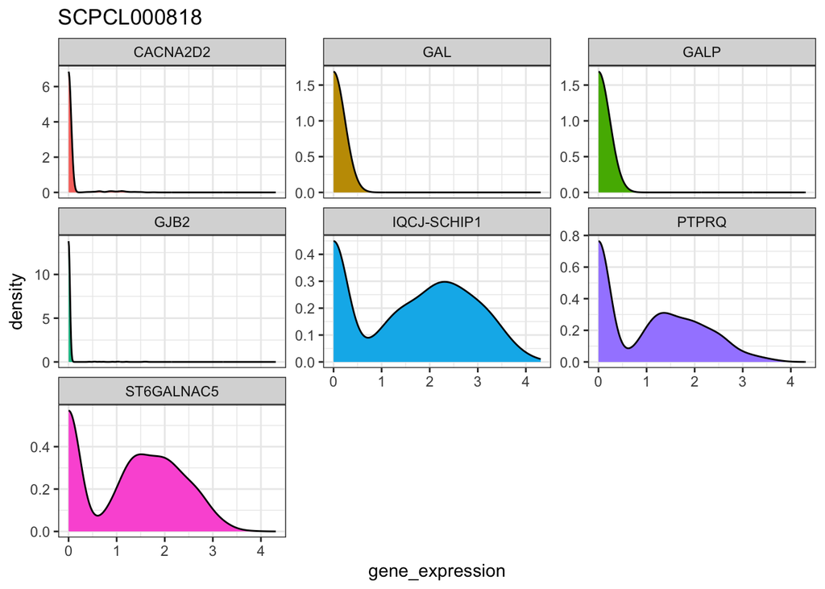

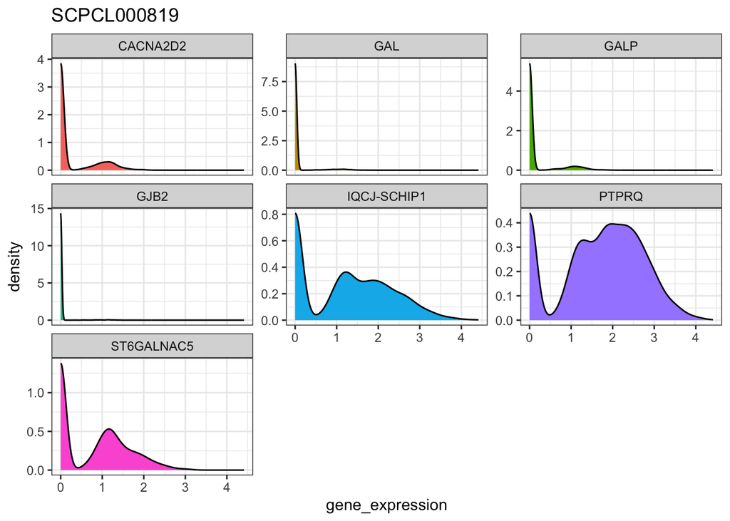

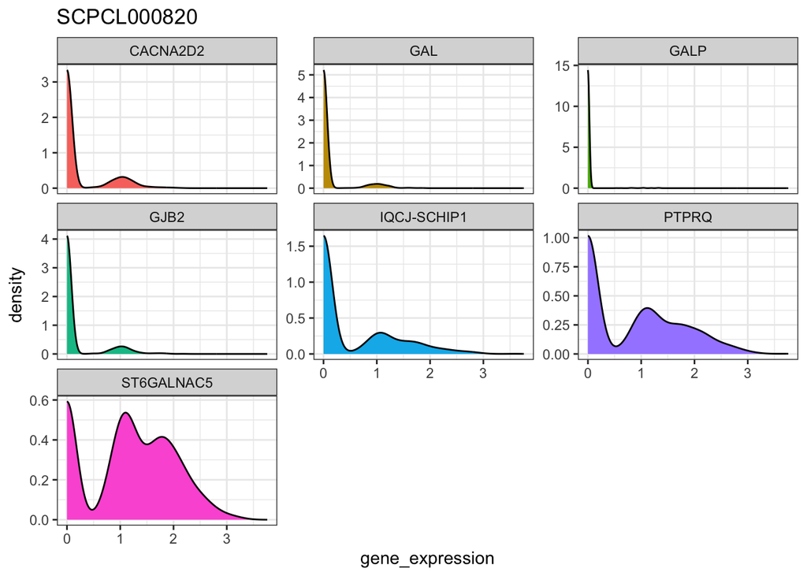

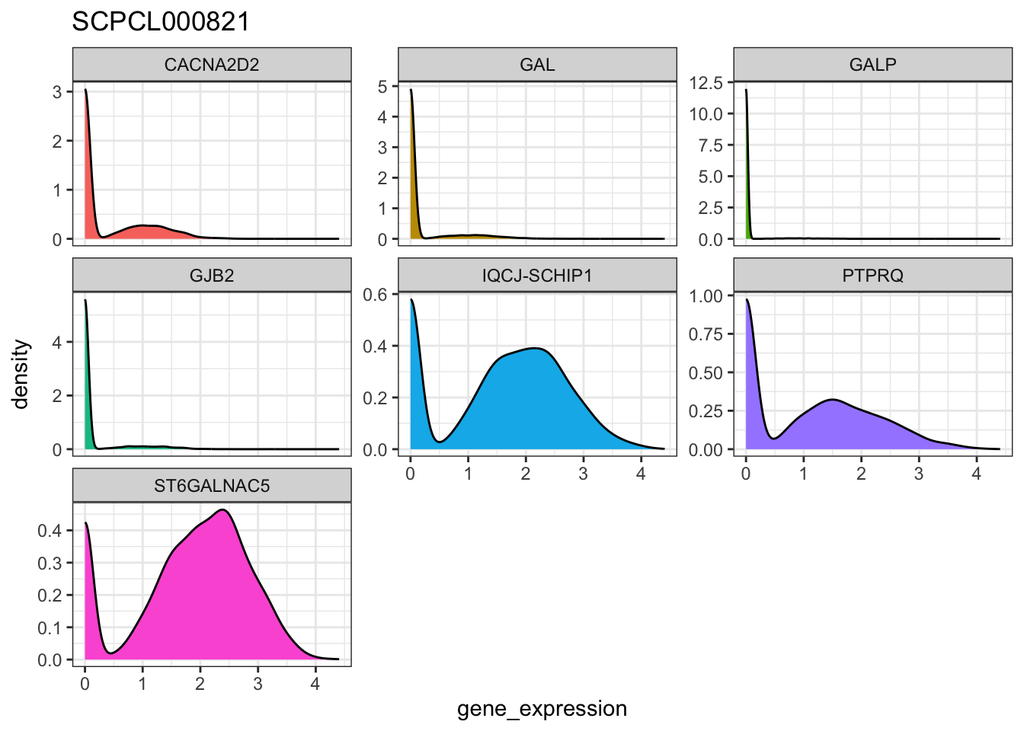

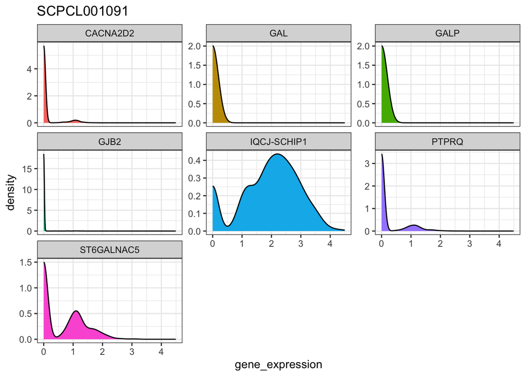

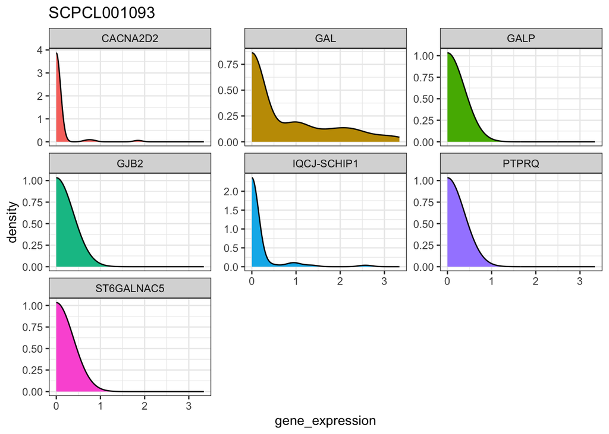

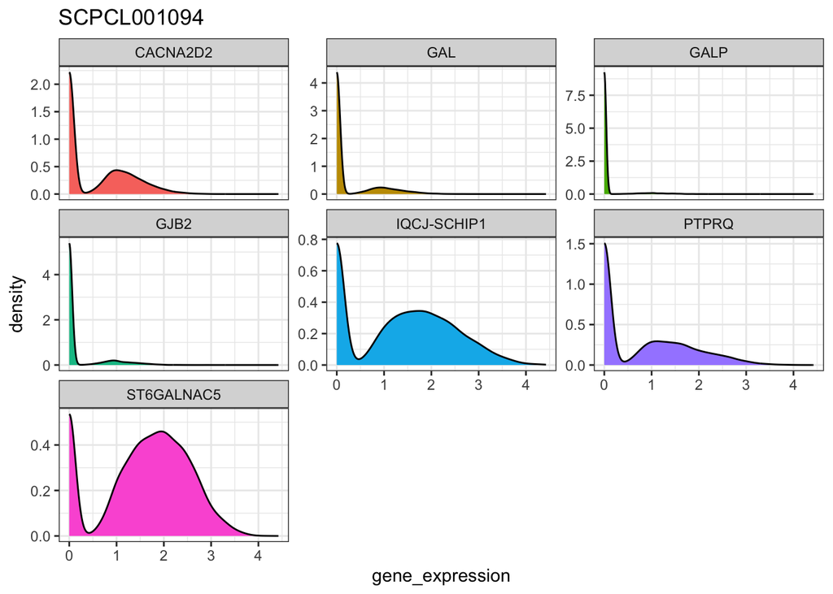

```r
for (i in 1:length(umap_df_list_excluded)) {
  p <- ggplot(
    umap_df_list_excluded[[i]],
    aes(x = gene_expression, fill = gene_symbol)
  ) +
    geom_density() +
    facet_wrap(vars(gene_symbol), scales = "free_y") +
    theme(legend.position = "none") +
    ggtitle(names(umap_df_list_excluded)[i])
  print(p)

  # save plots
  ggsave(
    filename = paste0(
      module_base,
      "/plots/marker_distribution_",
      names(umap_df_list)[i],
      ".png"
    ),
    plot = p,
    width = 6,
    height = 6,
    units = "in",
    dpi = 150
  )
}
```

Although we see some slight semblance of a bimodal distribution for most marker genes, it is hard to see and we cannot directly compare gene expression values across genes. This would make it hard to identify a cut off to categorize cells as expression or not expressing the marker gene.

Now we will transform each of the gene expression vectors by generating z-scores. Then we might be able to find a cut off we can use across samples for if marker genes are present in a cell or not.

```r
umap_df_list_excluded_scaled <- lapply(umap_df_list_excluded, function(x) {
  x |>
    dplyr::group_by(gene_symbol) |>
    # get z-scores for each gene
    dplyr::mutate(transformed_gene_expression = scale(gene_expression)[, 1]) |>
    dplyr::ungroup()
})
```

Now we can create the same density plot but looking at z-scores. Interestingly, in some samples, like SCPCS000489, we see that `ST6GALNAC5` has negative values. Presumably, these are tumor cells but there may be a skew due to the number of tumor cells compared to normal.

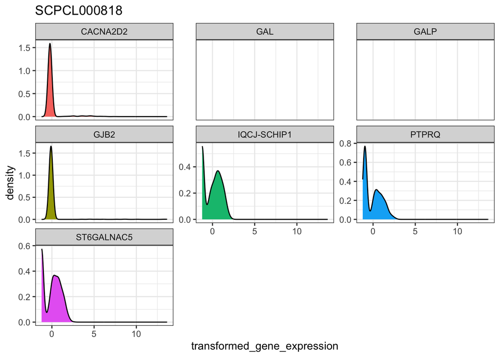

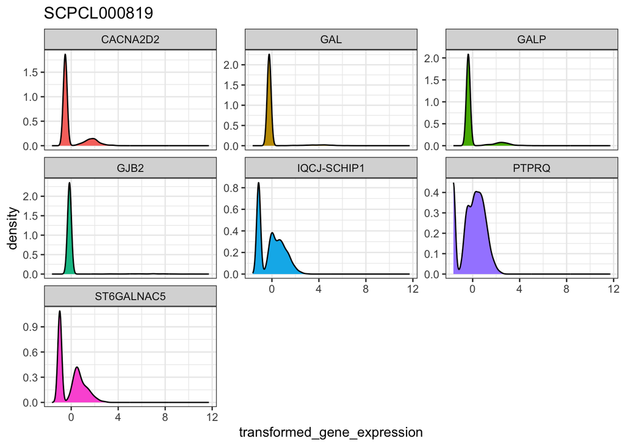

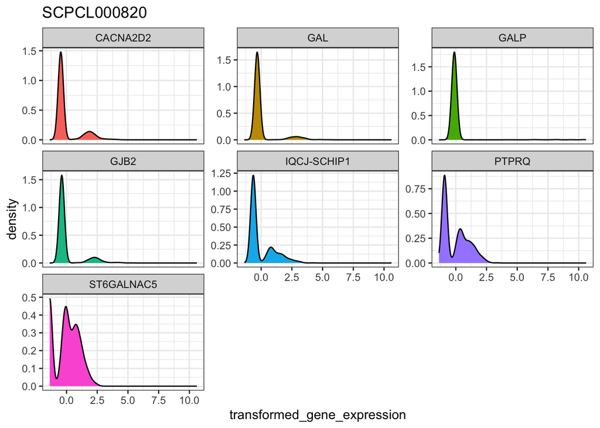

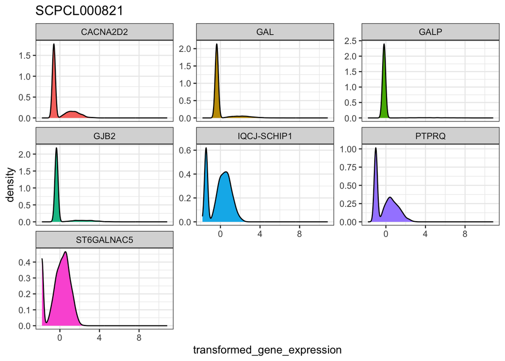

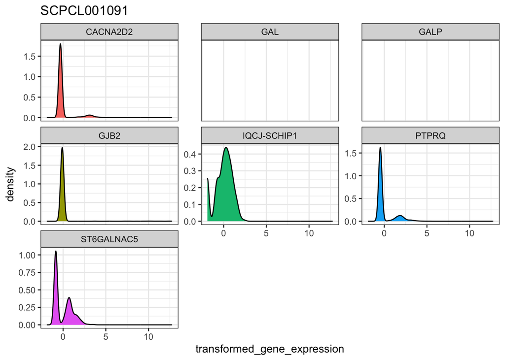

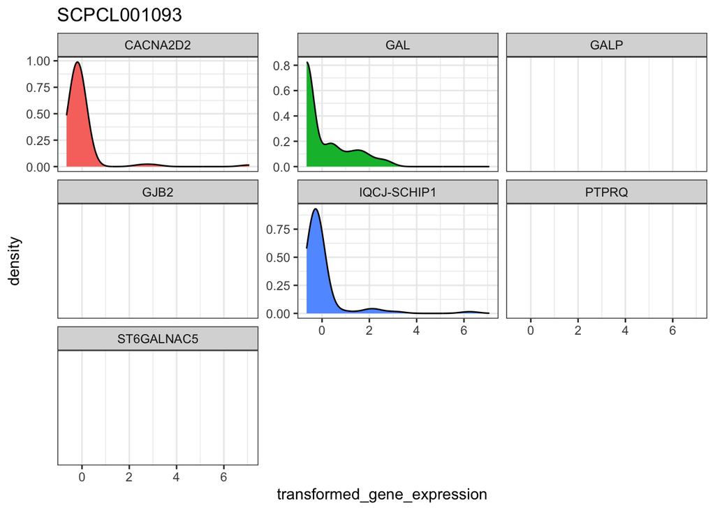

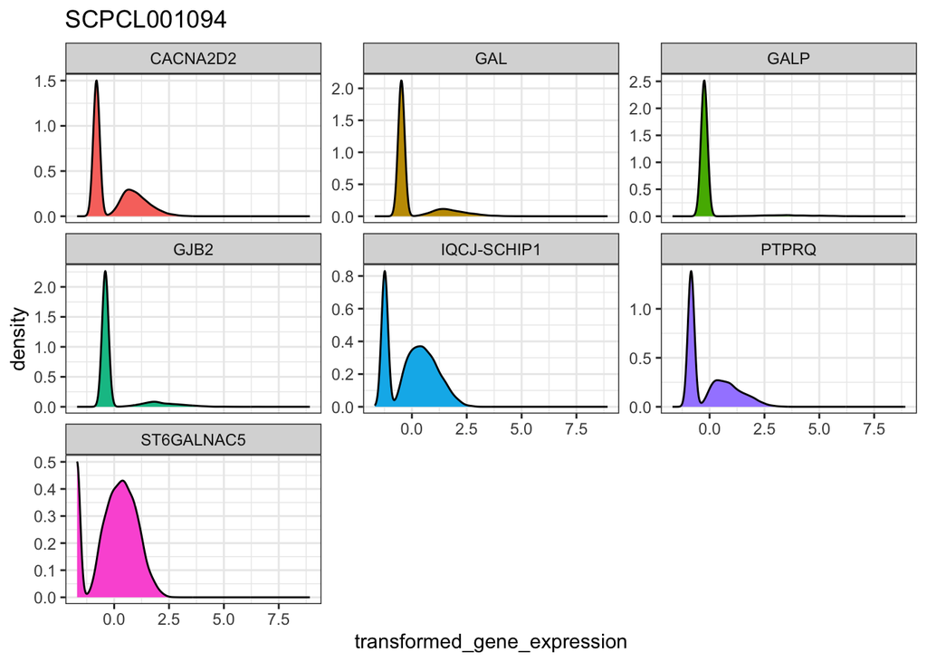

```r
for (i in 1:length(umap_df_list_excluded_scaled)) {
  p <- ggplot(
    umap_df_list_excluded_scaled[[i]],
    aes(x = transformed_gene_expression, fill = gene_symbol)
  ) +
    geom_density() +
    facet_wrap(vars(gene_symbol), scales = "free_y") +
    theme(legend.position = "none") +
    ggtitle(names(umap_df_list_excluded_scaled)[i])

  print(p)

  # save plots
  ggsave(
    filename = paste0(
      module_base,
      "/plots/marker_distribution_zscaled_",
      names(umap_df_list)[i],
      ".png"
    ),
    plot = p,
    width = 6,
    height = 6,
    units = "in",
    dpi = 150
  )
}
```

It looks like some marker genes have distinct groups of cells with z-score > 0, while other marker genes may not be as informative.

### Classify tumor cells using marker genes only

Let’s try and use the marker gene expression to classify tumor cells. It looks like we could use a cutoff of z-score > 0 to count that cell as a tumor cell.

We could either count any cell that expresses at least one marker gene > 0 as a tumor cell, or look at the combined expression. Let’s start with classifying tumor cells as tumor if any marker gene is present (z-score > 0).

Below, we can get the sum of the transformed gene expression of all marker genes and plot in a single UMAP.

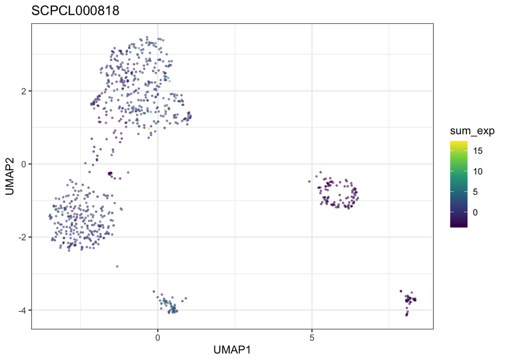

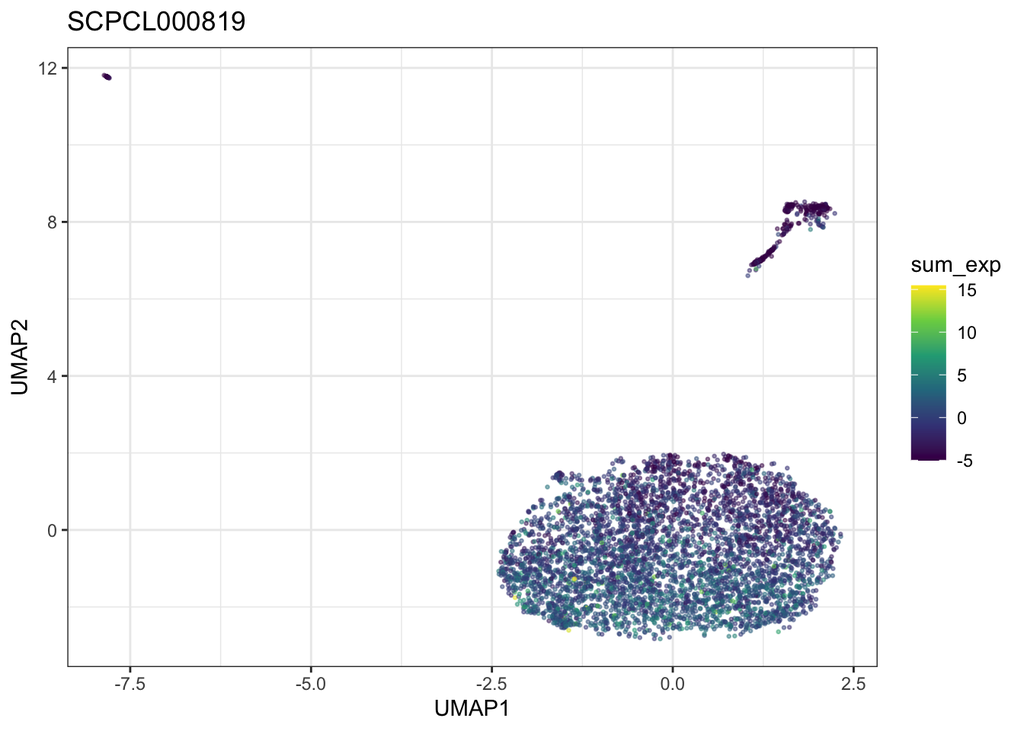

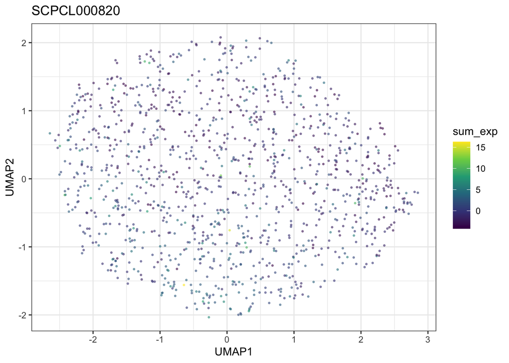

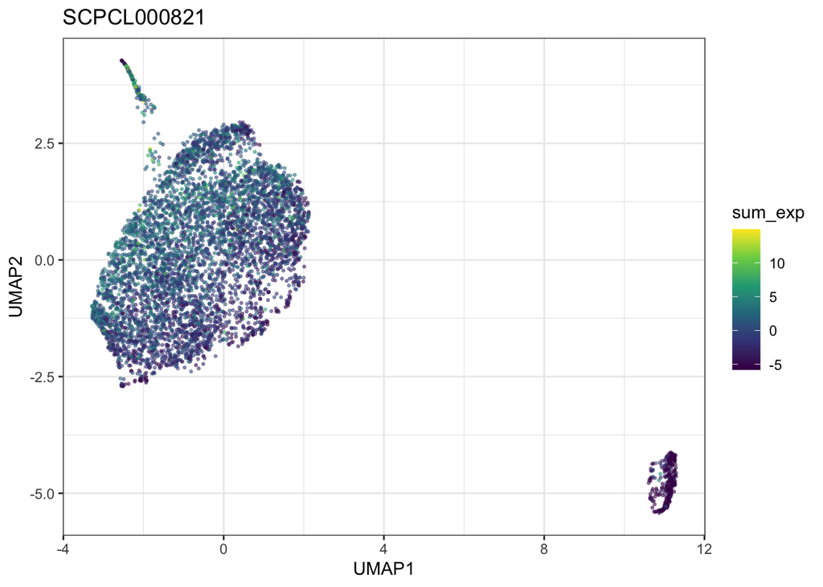

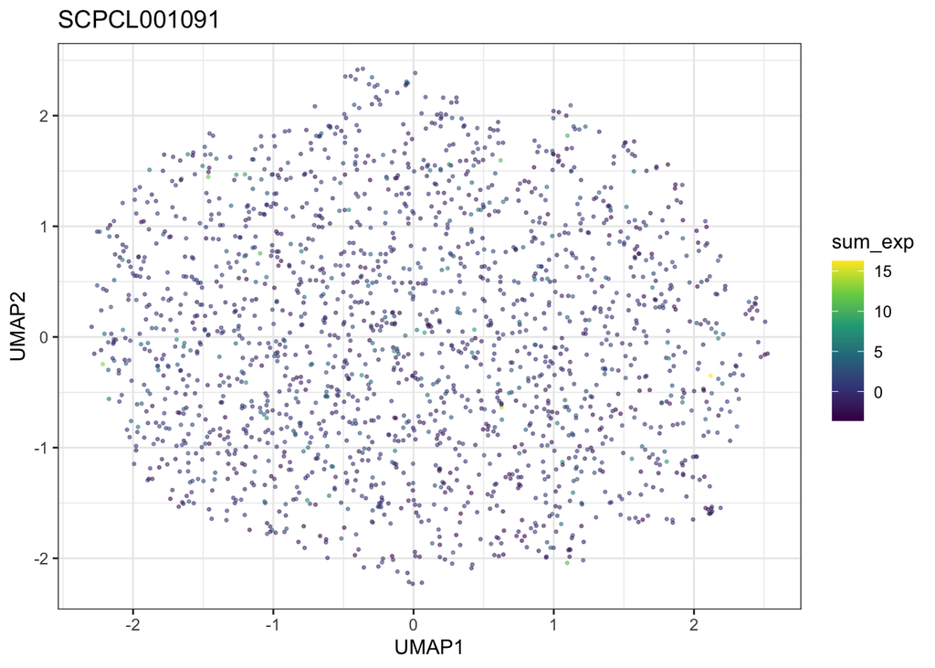

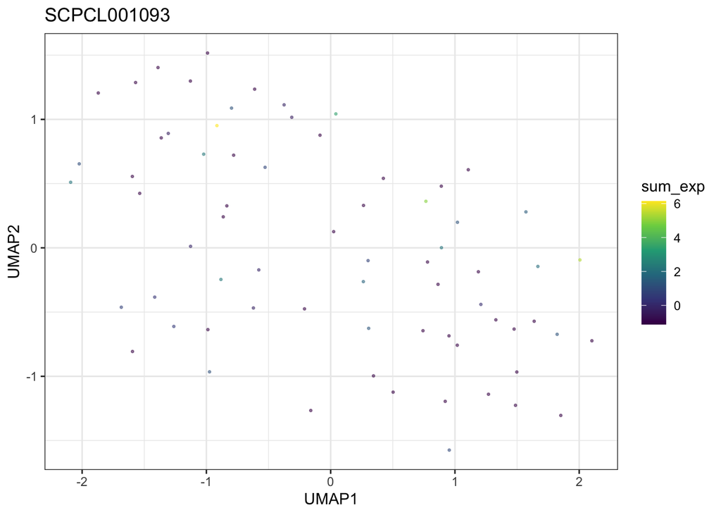

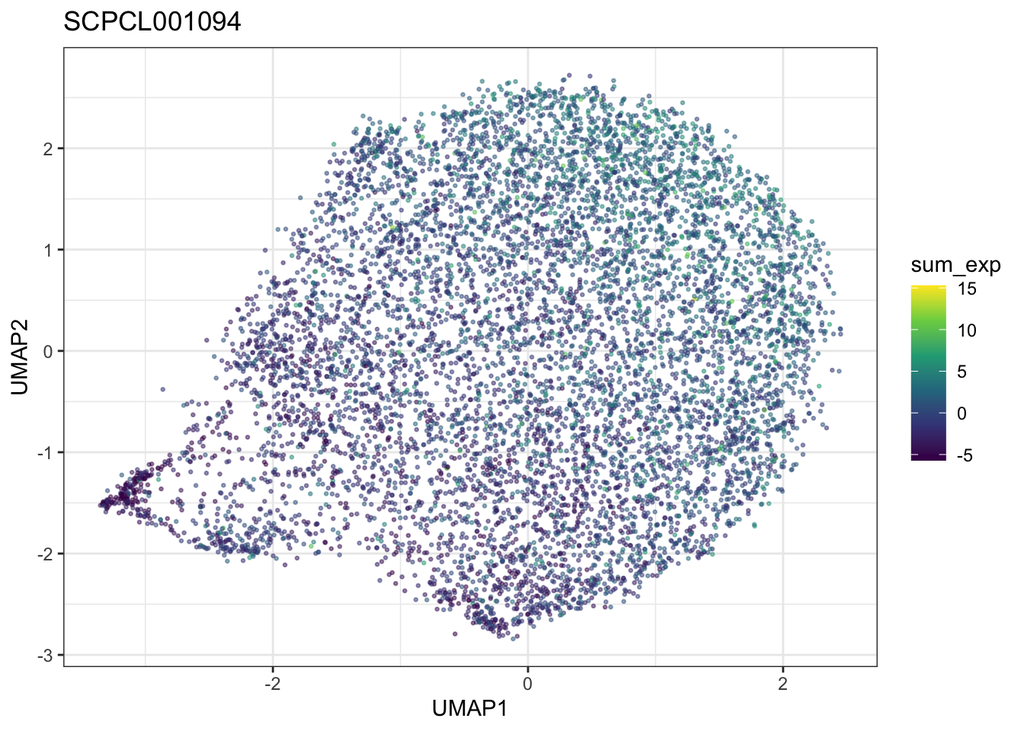

```r
# calculate sum gene expression across all marker genes in list
marker_sum_exp <- lapply(umap_df_list_excluded_scaled, function(x) {
  x |>
    dplyr::group_by(barcodes) |>
    dplyr::mutate(sum_exp = sum(transformed_gene_expression, na.rm = T)) |>
    dplyr::select(barcodes, UMAP1, UMAP2, sum_exp, cluster) |>
    dplyr::distinct()
})


# plot mean gene expression

for (i in 1:length(marker_sum_exp)) {
  p <- ggplot(marker_sum_exp[[i]], aes(x = UMAP1, y = UMAP2, color = sum_exp)) +
    geom_point(size = 0.5, alpha = 0.5) +
    scale_color_viridis_c() +
    ggtitle(names(umap_df_list_excluded_scaled)[i])
  print(p)

  # save plots
  ggsave(
    filename = paste0(
      module_base,
      "/plots/UMAP_marker_expression_",
      names(umap_df_list)[i],
      ".png"
    ),
    plot = p,
    width = 6,
    height = 6,
    units = "in",
    dpi = 150
  )
}
```

Now let’s classify any cell that has a sum of marker genes > 0 (after z-transformation) as tumor cells.

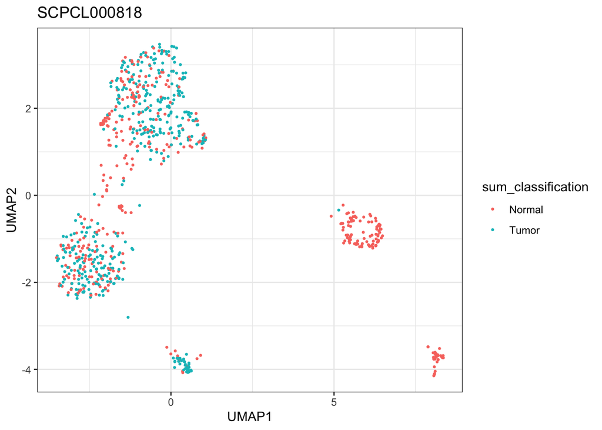

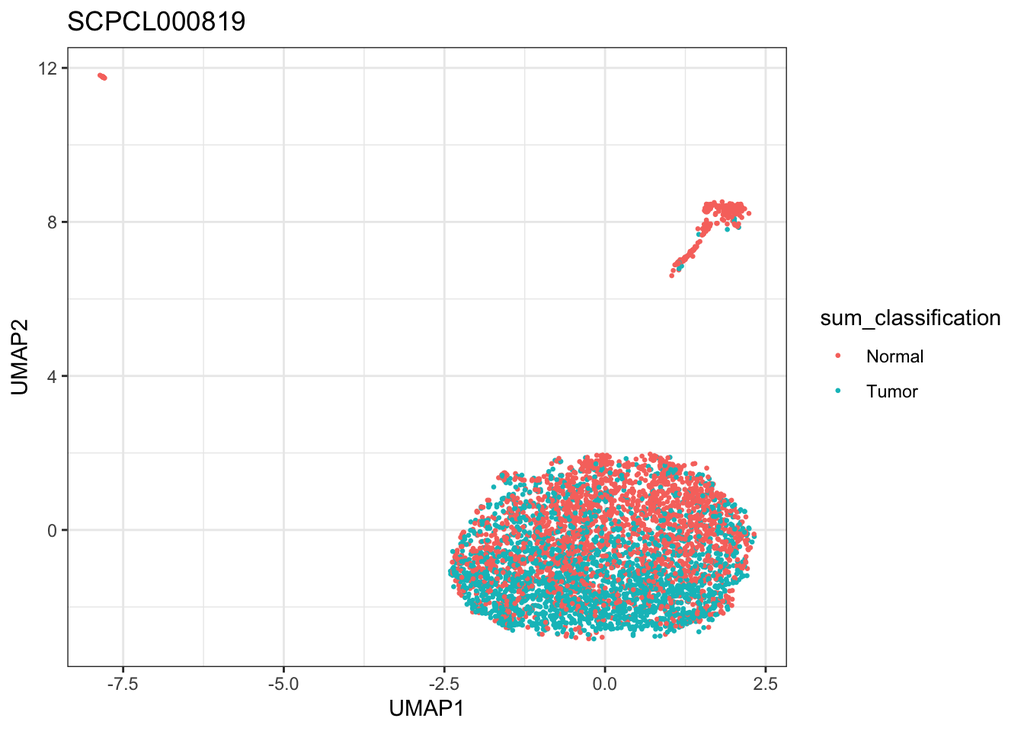

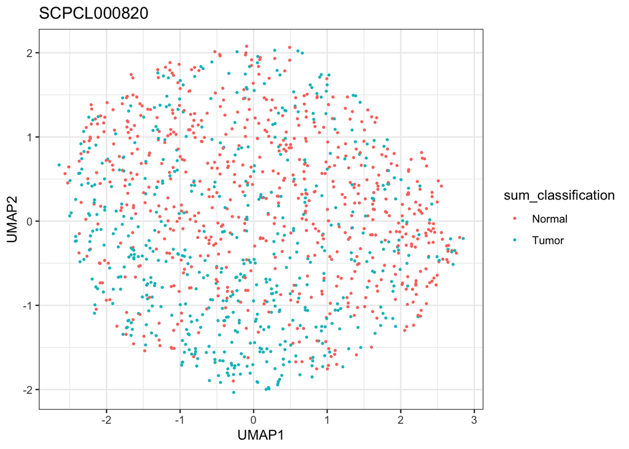

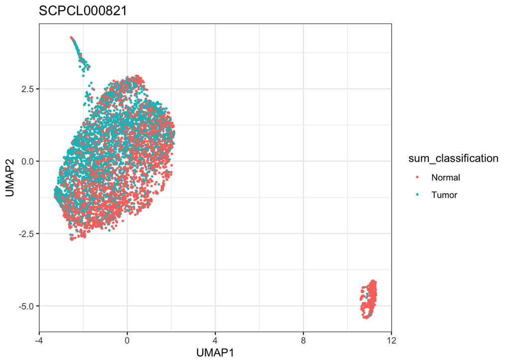

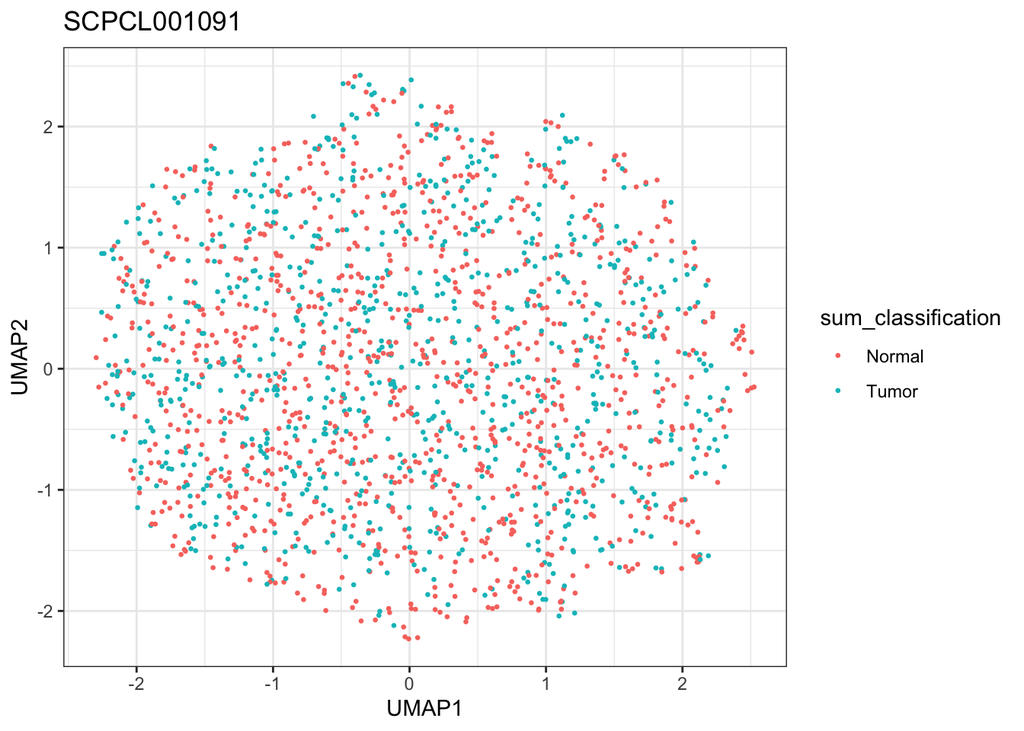

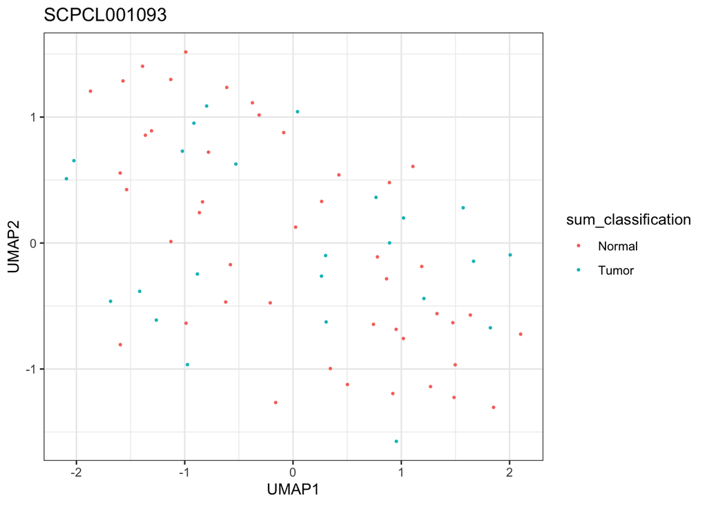

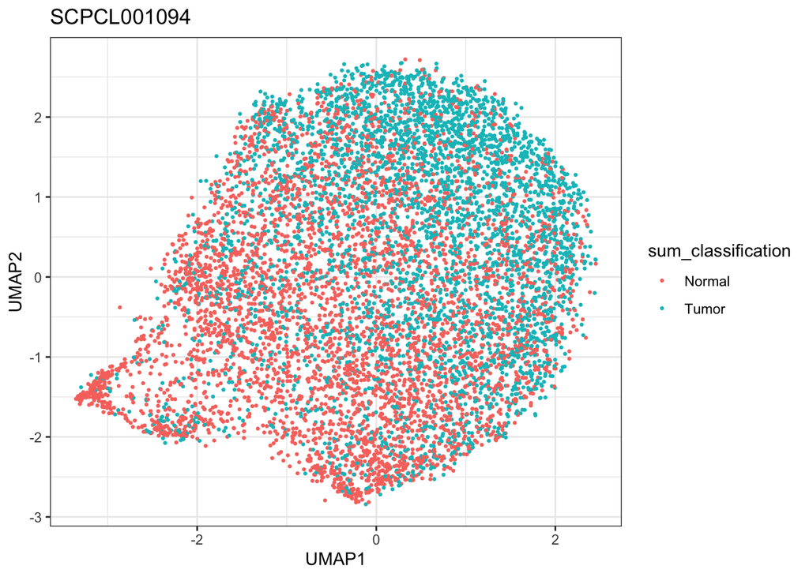

```r
# classify tumor cells based on presence of any marker genes
marker_sum_exp <- lapply(marker_sum_exp, function(x) {
  x |>
    dplyr::mutate(sum_classification = dplyr::if_else(sum_exp > 0, "Tumor", "Normal"))
})


for (i in 1:length(marker_sum_exp)) {
  p <- ggplot(marker_sum_exp[[i]], aes(x = UMAP1, y = UMAP2, color = sum_classification)) +
    geom_point(size = 0.5, alpha = 1) +
    ggtitle(names(umap_df_list_excluded_scaled)[i])
  print(p)

  # save plots
  ggsave(
    filename = paste0(
      module_base,
      "/plots/UMAP_classification_",
      names(umap_df_list)[i],
      ".png"
    ),
    plot = p,
    width = 6,
    height = 6,
    units = "in",
    dpi = 150
  )
}
```

This gives us a rough idea of cells that may be classified as tumor cells. However, I believe re-doing this analysis using the cluster level data may give us better results. This is highly dependent on whether the clusters were generated with enough granularity.